# RStudy of Training Metrics on Operational Effectiveness

To investigate the potential correlation between operational effectiveness and pipeline training completion, we first compiled several salient statistics about individuals within the company - i.e. grade, time in grade, time on station, SANS Courses, common cyber certifications, pipeline training complete, JQR/JQS complete, education, etc. We then polled across team leadership to get their perceptions of operational impact and effectiveness for each of the personnel on their respective teams. To do this, we asked them to assess each person on a 1-10 scale, with the following word descriptions to guide feedback: 1 - Negative Value, I would be better without. 3- No value, I could lose tomorrow and nothing would change 5 - Minimal value, I would need to replace his work roles but it shouldn’t be hard 7 - Large value, highly qualified, there are few who could replace him 9 - Immense value, absolute star and center of gravity who could not be replaced 10 - Person is a Unicorn - only person in the Army doing what they are doing

We will begin by loading in the data and looking at the nature of the data

```r
quality <- read.csv("QualityMetrics.csv")
str(quality)
```

```
'data.frame':   145 obs. of  44 variables:
 $ OperationalQuality     : int  3 3 4 4 6 3 4 7 5 2 ...
 $ Team                   : Factor w/ 3 levels "01 CPT","23 CPT",..: 2 3 3 3 3 3 3 3 3 3 ...
 $ Rank                   : Factor w/ 16 levels "1LT","1SG","CIV",..: 9 15 14 15 14 3 11 5 14 4 ...
 $ TimeinGrade            : int  48 12 19 7 14 16 7 48 23 59 ...
 $ TimeonStation          : int  24 9 32 18 29 16 16 30 38 2 ...
 $ Badged                 : int  1 0 1 1 1 1 1 1 1 1 ...
 $ WorkRole               : Factor w/ 24 levels "1SG","ASIA","CND MGR",..: 3 24 9 10 11 11 9 19 9 19 ...
 $ PriorCombatArms        : Factor w/ 2 levels "no","yes": 1 1 1 1 1 1 1 1 1 1 ...
 $ Degree                 : Factor w/ 4 levels "associates","bachelors",..: 2 2 4 2 4 2 4 1 4 3 ...
 $ DegreeType             : Factor w/ 7 levels "CS","EE","IT",..: 5 2 6 5 6 1 6 5 6 3 ...
 $ UndergraduateUniversity: Factor w/ 4 levels "none","Not USMA",..: 2 2 1 2 1 2 1 2 1 2 ...
 $ ILE                    : int  1 0 0 0 0 0 0 0 0 0 ...
 $ Captain.sCareerCourse  : int  1 0 0 0 0 0 0 0 0 1 ...
 $ WOILE                  : int  0 0 0 0 0 0 0 0 0 0 ...
```

[output cut: 30 more lines]

```r
summary(quality)
```

```
 OperationalQuality     Team         Rank     TimeinGrade    TimeonStation       Badged                 WorkRole
 Min.   : 1.000     01 CPT:39   SSG    :27   Min.   : 0.00   Min.   : 2.00   Min.   :0.0000   CYBER OPS NCO :17
 1st Qu.: 4.000     23 CPT:39   SGT    :23   1st Qu.:12.00   1st Qu.:13.00   1st Qu.:1.0000   DNEA          :15
 Median : 6.000     23 NMT:67   SPC    :22   Median :24.00   Median :26.00   Median :1.0000   CND MGR       :14
 Mean   : 5.352                 CIV    :16   Mean   :29.79   Mean   :27.97   Mean   :0.9103   ASIA          :13
 3rd Qu.: 7.000                 CPT    :13   3rd Qu.:47.00   3rd Qu.:36.00   3rd Qu.:1.0000   CYBER OPS TECH: 8
 Max.   :10.000                 CW3    : 9   Max.   :95.00   Max.   :86.00   Max.   :1.0000   SEL           : 7
                                (Other):35                                                    (Other)       :71
 PriorCombatArms        Degree        DegreeType UndergraduateUniversity      ILE          Captain.sCareerCourse
 no :136         associates:25   CS        :12   none    :51             Min.   :0.00000   Min.   :0.0000
 yes:  9         bachelors :61   EE        : 3   Not USMA:72             1st Qu.:0.00000   1st Qu.:0.0000
                 masters   : 9   IT        :14   Online  :10             Median :0.00000   Median :0.0000
                 none      :50   Math      : 3   USMA    :12             Mean   :0.01379   Mean   :0.1172
                                 non-STEM  :37                           3rd Qu.:0.00000   3rd Qu.:0.0000
                                 none      :50                           Max.   :1.00000   Max.   :1.0000
                                 STEM-Other:26
     WOILE              WOAC              ALC              WLC              SLC              SEC508
 Min.   :0.00000   Min.   :0.00000   Min.   :0.0000   Min.   :0.0000   Min.   :0.00000   Min.   :0.00000
 1st Qu.:0.00000   1st Qu.:0.00000   1st Qu.:0.0000   1st Qu.:0.0000   1st Qu.:0.00000   1st Qu.:0.00000
 Median :0.00000   Median :0.00000   Median :0.0000   Median :0.0000   Median :0.00000   Median :0.00000
 Mean   :0.02759   Mean   :0.09655   Mean   :0.2621   Mean   :0.4414   Mean   :0.08966   Mean   :0.05517
 3rd Qu.:0.00000   3rd Qu.:0.00000   3rd Qu.:1.0000   3rd Qu.:1.0000   3rd Qu.:0.00000   3rd Qu.:0.00000
 Max.   :1.00000   Max.   :1.00000   Max.   :1.0000   Max.   :1.0000   Max.   :1.00000   Max.   :1.00000

     SEC408        SEC401.GSEC.    SEC501..GCED.     FOR500.GCFE.     SEC504..GCIH.     SEC503..GCIA.
 Min.   :0.0000   Min.   :0.0000   Min.   :0.0000   Min.   :0.00000   Min.   :0.00000   Min.   :0.00000
 1st Qu.:0.0000   1st Qu.:0.0000   1st Qu.:0.0000   1st Qu.:0.00000   1st Qu.:0.00000   1st Qu.:0.00000
 Median :0.0000   Median :0.0000   Median :0.0000   Median :0.00000   Median :0.00000   Median :0.00000
 Mean   :0.1103   Mean   :0.2552   Mean   :0.1448   Mean   :0.08966   Mean   :0.06897   Mean   :0.04138
 3rd Qu.:0.0000   3rd Qu.:1.0000   3rd Qu.:0.0000   3rd Qu.:0.00000   3rd Qu.:0.00000   3rd Qu.:0.00000
 Max.   :1.0000   Max.   :1.0000   Max.   :1.0000   Max.   :1.00000   Max.   :1.00000   Max.   :1.00000

 SEC560..GPEN.      SEC301.GISF.        AnySANS            JNAC             JACWC          ACOPC.JCOPC
 Min.   :0.00000   Min.   :0.00000   Min.   :0.0000   Min.   :0.00000   Min.   :0.00000   Min.   :0.00000
 1st Qu.:0.00000   1st Qu.:0.00000   1st Qu.:0.0000   1st Qu.:0.00000   1st Qu.:0.00000   1st Qu.:0.00000
 Median :0.00000   Median :0.00000   Median :0.0000   Median :0.00000   Median :0.00000   Median :0.00000
 Mean   :0.04138   Mean   :0.03448   Mean   :0.2966   Mean   :0.05517   Mean   :0.06207   Mean   :0.04828
 3rd Qu.:0.00000   3rd Qu.:0.00000   3rd Qu.:1.0000   3rd Qu.:0.00000   3rd Qu.:0.00000   3rd Qu.:0.00000
 Max.   :1.00000   Max.   :1.00000   Max.   :1.0000   Max.   :1.00000   Max.   :1.00000   Max.   :1.00000

```

[output cut: 8 more lines]

```
      SEC.             NET.             CEH           CCNA            AnyCert       PipelineComplete
 Min.   :0.0000   Min.   :0.0000   Min.   :0.0   Min.   :0.00000   Min.   :0.0000   Min.   :0.0000
 1st Qu.:0.0000   1st Qu.:0.0000   1st Qu.:0.0   1st Qu.:0.00000   1st Qu.:0.0000   1st Qu.:0.0000
 Median :1.0000   Median :1.0000   Median :0.0   Median :0.00000   Median :1.0000   Median :1.0000
 Mean   :0.5034   Mean   :0.5379   Mean   :0.2   Mean   :0.09655   Mean   :0.6276   Mean   :0.6069
 3rd Qu.:1.0000   3rd Qu.:1.0000   3rd Qu.:0.0   3rd Qu.:0.00000   3rd Qu.:1.0000   3rd Qu.:1.0000
 Max.   :1.0000   Max.   :1.0000   Max.   :1.0   Max.   :1.00000   Max.   :1.0000   Max.   :1.0000

 JQR.JQSComplete
 Min.   :0.0000
 1st Qu.:0.0000
 Median :1.0000
 Mean   :0.5724
 3rd Qu.:1.0000
 Max.   :1.0000
```

As we can see, it is about a company’s worth of personnel, with a very complete data set. This is, however, a rather small data set for most machine learning and statistics

Next, we will analyze some of the common training measures and usual measures of personnel effectivess and their correlation to operational effectiveness. We will use a Spearmen correlation coefficient for this measure, as the response variable is ordinal (i.e. quality ranking from 1 to 10).

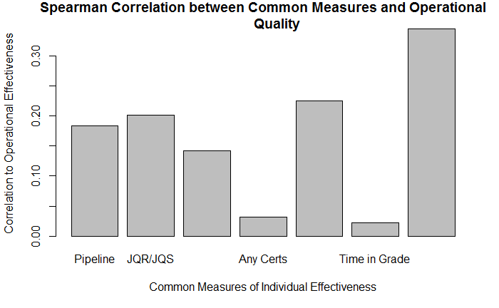

```r
ct1 <- cor(quality$OperationalQuality, quality$PipelineComplete, method ="spearman")
ct2 <- cor(quality$OperationalQuality, quality$JQR.JQSComplete, method ="spearman")
ct3 <- cor(quality$OperationalQuality, quality$AnySANS, method ="spearman")
ct4 <- cor(quality$OperationalQuality, quality$AnyCert, method ="spearman")
ct5 <- cor(quality$OperationalQuality, quality$TimeonStation, method ="spearman")
ct6 <- cor(quality$OperationalQuality, quality$TimeinGrade, method ="spearman")
ct7 <- cor(quality$OperationalQuality, quality$Badged, method ="spearman")
names1 =c("Pipeline", "JQR/JQS", "Any SANS Courses", "Any Certs", "Time on Station", "Time in Grade", "Badged")
barplot(c(ct1,ct2,ct3,ct4,ct5, ct6, ct7), names.arg = names1, main = "Spearman Correlation between Common Measures and Operational
        Quality", xlab="Common Measures of Individual Effectiveness", ylab = "Correlation to Operational Effectiveness")
```

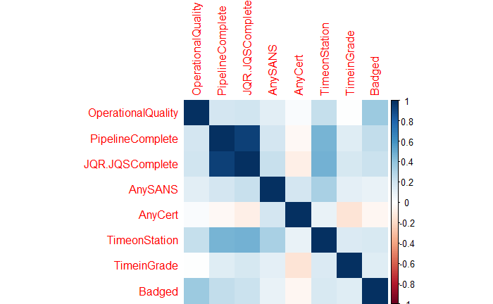

```r
library(corrplot)
corMat <- cor(data.frame(quality[, c("OperationalQuality", "PipelineComplete", "JQR.JQSComplete", "AnySANS", "AnyCert",
                                     "TimeonStation", "TimeinGrade", "Badged")]))
corrplot(corMat, method = "color")
```

As can be seen, nothing is strongly correlated with operational effectiveness. The only strong correlation is between pipeline complete and JQR/JQS complete; this should make sense given that the two often go hand-in-hand. Time on Station and being Badged have the most correlation to Operational Quality

Having looked at some common measures, lest investigate various possible sub categroies for their salience in operational effectives. We will start with rank:

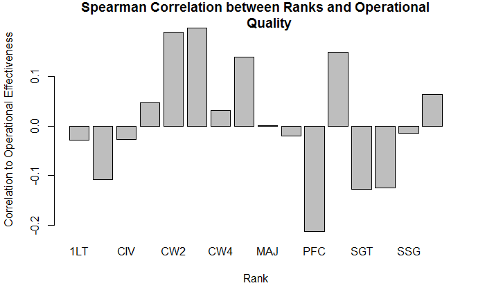

```r
cr1 <- cor(quality$OperationalQuality, model.matrix(~quality$Rank-1), method ="spearman")
names2 <- c("1LT", "1SG", "CIV", "CPT", "CW2", "CW3", "CW4", "LTC", "MAJ", "MSG", "PFC", "SFC", "SGT", "SPC", "SSG", "W01")
barplot(cr1[1:16], names.arg = names2, main = "Spearman Correlation between Ranks and Operational
        Quality", xlab="Rank", ylab = "Correlation to Operational Effectiveness")
```

In this case, it appears that some ranks do have some moderately strong correlation, to include negative correlation. In particular, it seems enlisted and NCO ranks are usually negatively correlated with operational effectiveness, while officer ranks are positively correlated.

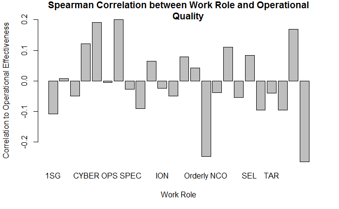

```r
cr5 <- cor(quality$OperationalQuality, model.matrix(~quality$WorkRole-1), method ="spearman")
names6 <- c("1SG", "ASIA", "CND MGR", "Commander", "CYBER OPS NCO", "CYBER OPS SPEC", "CYBER OPS TECH", "Deputy",
            "DNEA", "EA", "ION", "LA", "NCOIC", "NET INFRA SVC SPEC", "Orderly NCO", "OTDA", "Planner", "SECURITY ANALYST",
            "SEL", "SYSTEMS ARCHITECT", "TAR", "TDNA", "Team Lead", "Training NCO")
barplot(cr5[1:24], names.arg = names6, main = "Spearman Correlation between Work Role and Operational
        Quality", xlab="Work Role", ylab = "Correlation to Operational Effectiveness")
```

So, it seems work roles does have some impacts on operational effectiveness. In particular, administartive roles like Orderly Room or Training Room are quite negatively correlated to operational effectiveness.

Next, lets investigate if having a degree - to include type, and where the degree was obtained from - have any correlation to operational effectiveness.

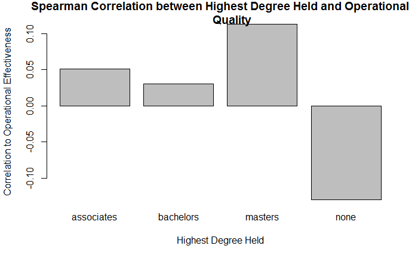

```r
cr2 <- cor(quality$OperationalQuality, model.matrix(~quality$Degree-1), method ="spearman")
names3 <- c("associates", "bachelors", "masters", "none")
barplot(cr2[1:4], names.arg = names3, main = "Spearman Correlation between Highest Degree Held and Operational
        Quality", xlab="Highest Degree Held", ylab = "Correlation to Operational Effectiveness")
```

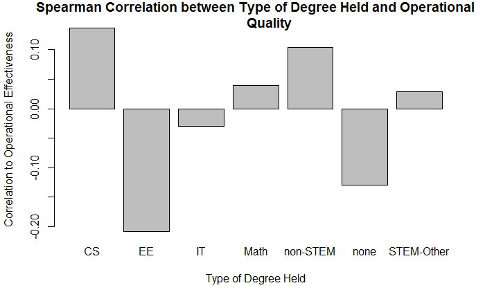

```r
cr3 <- cor(quality$OperationalQuality, model.matrix(~quality$DegreeType-1), method ="spearman")
names4 <- c("CS", "EE", "IT", "Math", "non-STEM", "none", "STEM-Other")
barplot(cr3[1:7], names.arg = names4, main = "Spearman Correlation between Type of Degree Held and Operational
        Quality", xlab="Type of Degree Held", ylab = "Correlation to Operational Effectiveness")
```

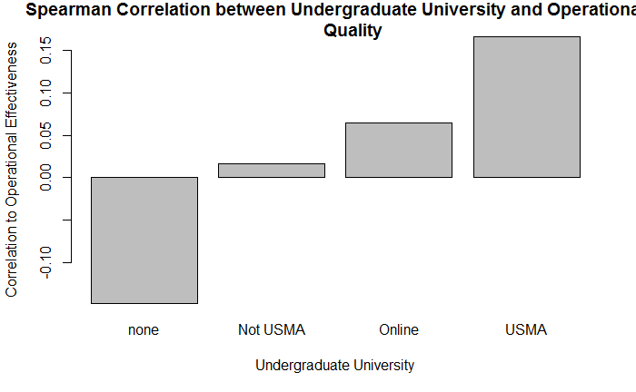

```r
cr4 <- cor(quality$OperationalQuality, model.matrix(~quality$UndergraduateUniversity-1), method ="spearman")
names5 <- c("none", "Not USMA", "Online", "USMA")
barplot(cr4[1:4], names.arg = names5, main = "Spearman Correlation between Undergraduate University and Operational
        Quality", xlab="Undergraduate University", ylab = "Correlation to Operational Effectiveness")
```

There are some rather intersting results. First, having no degree is negatively correlated with Operational effectiveness in every case. In other words, degrees are important in some respect to operational effectiveness. Also interesting is that CS, Math, and Non-STEM degrees are positively correlated, while EE and IT are negatively correlated. This could be a result of the small number of people within the data set possessing these degress and there operational effectiveness is likely decreased for other reasons.

All in all, while there are some interesting trends, correlation between operational effectiveness and the various factors studied here are generally low - highest correlation is under 0.5. Thus, there is more than likely a confluence of factors that are significant (i.e. officer, with a degree in CS may correlate highly) and that the metrics we are using, like Pipeline complete are not representative of actual operational effectivness of a person

As a brief aside, we will alo take a look at a correlation matrix for SANS and certification courses

[figure not shown]

```r
corMat <- cor(data.frame(quality[, c("OperationalQuality", "SEC508", "SEC408", "SEC401.GSEC.", "SEC501..GCED.",
                                     "FOR500.GCFE.", "SEC504..GCIH.", "SEC503..GCIA.", "SEC560..GPEN.", "SEC301.GISF.",
                                     "CISSP", "OSCP", "A.", "SEC.", "NET.", "CEH", "CCNA")]))
corrplot(corMat, method = "color")
```

Not surprisngly, SANS courses tend to correlate, as to SEC+, NET+, and CEH. However, none of the correlate strongly to Operational Quality. In fact, SEC508, SEC408, and CISSP are slightly negatively correlated.

Now, we would like to see if we can produce any kind of predictive model for operational quality. To do this, we will first need to remove some of the less important columns to reduce the dimensionality of the data set; we do not have enough data to succesfully fit a model using all of the possible feature vectors.

```r
linCols <- c("OperationalQuality", "Rank", "TimeinGrade", "TimeonStation", "Badged", "WorkRole", "Degree", "DegreeType",
             "UndergraduateUniversity", "AnySANS", "AnyCert", "JQR.JQSComplete")
linearQuality <- quality[linCols]
```

We will begin by investigating a linear regression model. This model assumes statistical independence among the feature vectors, and a numerical - as oppsoed to categorical - response variable (which, in this case is not structly true).

```r
model1 <- lm(OperationalQuality ~., data=linearQuality)
summary(model1)
```

```
Call:
lm(formula = OperationalQuality ~ ., data = linearQuality)

Residuals:
    Min      1Q  Median      3Q     Max
-4.3828 -0.7249 -0.0153  0.9459  3.2719

Coefficients: (2 not defined because of singularities)
                                 Estimate Std. Error t value Pr(>|t|)
(Intercept)                      1.476528   3.644916   0.405   0.6864
Rank1SG                          0.060656   3.245899   0.019   0.9851
RankCIV                          1.881740   2.267178   0.830   0.4087
RankCPT                          1.737774   1.500334   1.158   0.2498
RankCW2                          2.762107   1.992638   1.386   0.1691
RankCW3                          3.647424   2.250464   1.621   0.1086
RankCW4                          2.111363   2.599924   0.812   0.4189
RankLTC                          1.659531   2.749795   0.604   0.5477
RankMAJ                         -0.575280   2.115032  -0.272   0.7862
RankMSG                         -0.456950   2.540182  -0.180   0.8576
RankPFC                          0.528475   2.596796   0.204   0.8392
RankSFC                          1.709625   2.624435   0.651   0.5164
RankSGT                          0.756760   2.410413   0.314   0.7543
RankSPC                          1.264061   2.393209   0.528   0.5987
RankSSG                          1.484952   2.297753   0.646   0.5198
RankWO1                          2.012153   2.277749   0.883   0.3794
TimeinGrade                     -0.019929   0.009226  -2.160   0.0334 *
TimeonStation                    0.008814   0.013756   0.641   0.5234
Badged                           0.885589   0.996518   0.889   0.3765
WorkRoleASIA                     0.683882   1.246086   0.549   0.5845
WorkRoleCND MGR                  1.243581   1.914370   0.650   0.5176
WorkRoleCommander                2.650047   2.887044   0.918   0.3611
WorkRoleCYBER OPS NCO            1.936303   1.234360   1.569   0.1202
WorkRoleCYBER OPS SPEC           1.577879   1.493911   1.056   0.2937
WorkRoleCYBER OPS TECH           0.693276   1.757109   0.395   0.6941
WorkRoleDeputy                  -0.140145   1.718161  -0.082   0.9352
WorkRoleDNEA                     0.023272   1.319283   0.018   0.9860
WorkRoleEA                       1.101859   1.475464   0.747   0.4571
WorkRoleION                      0.400614   1.418010   0.283   0.7782
WorkRoleLA                       0.130946   1.505123   0.087   0.9309
WorkRoleNCOIC                    1.737354   1.724542   1.007   0.3164
```

[output cut: 17 more lines]

```
DegreeTypenon-STEM              -0.272389   0.828586  -0.329   0.7431
DegreeTypenone                         NA         NA      NA       NA
DegreeTypeSTEM-Other            -0.576229   0.849009  -0.679   0.4991
UndergraduateUniversityNot USMA  1.752301   2.380272   0.736   0.4635
UndergraduateUniversityOnline    1.946815   2.368142   0.822   0.4132
UndergraduateUniversityUSMA      2.050013   2.953243   0.694   0.4894
AnySANS                         -0.024990   0.486260  -0.051   0.9591
AnyCert                         -0.294115   0.410895  -0.716   0.4760
JQR.JQSComplete                  0.570234   0.463172   1.231   0.2215
---
Signif. codes:  0 *** 0.001 ** 0.01 * 0.05 . 0.1   1

Residual standard error: 1.68 on 90 degrees of freedom
Multiple R-squared:  0.5199,    Adjusted R-squared:  0.2318
F-statistic: 1.805 on 54 and 90 DF,  p-value: 0.006565
```

```r
model2<- step(model1)
```

```
Start:  AIC=191.29
OperationalQuality ~ Rank + TimeinGrade + TimeonStation + Badged +
    WorkRole + Degree + DegreeType + UndergraduateUniversity +
    AnySANS + AnyCert + JQR.JQSComplete

                          Df Sum of Sq    RSS    AIC
- WorkRole                22    66.474 320.49 181.00
- UndergraduateUniversity  3     1.986 256.00 186.42
- Rank                    14    46.090 300.10 187.47
- AnySANS                  1     0.007 254.02 189.30
- DegreeType               5    15.304 269.31 189.78
- TimeonStation            1     1.159 255.17 189.95
- AnyCert                  1     1.446 255.46 190.12
- Degree                   2     5.284 259.30 190.28
- Badged                   1     2.229 256.24 190.56
<none>                                 254.01 191.29
- JQR.JQSComplete          1     4.278 258.29 191.72
- TimeinGrade              1    13.168 267.18 196.62

Step:  AIC=181
OperationalQuality ~ Rank + TimeinGrade + TimeonStation + Badged +
    Degree + DegreeType + UndergraduateUniversity + AnySANS +
    AnyCert + JQR.JQSComplete

                          Df Sum of Sq    RSS    AIC
- UndergraduateUniversity  3     1.078 321.56 175.49
- Rank                    15    66.296 386.78 178.26
- Degree                   2     3.936 324.42 178.77
- JQR.JQSComplete          1     0.116 320.60 179.05
- AnySANS                  1     0.312 320.80 179.14
- AnyCert                  1     1.335 321.82 179.60
<none>                                 320.49 181.00
- TimeonStation            1     6.688 327.17 182.00
- TimeinGrade              1    10.094 330.58 183.50
- DegreeType               5    31.490 351.97 184.59
- Badged                   1    21.002 341.49 188.20

Step:  AIC=175.49
OperationalQuality ~ Rank + TimeinGrade + TimeonStation + Badged +
    Degree + DegreeType + AnySANS + AnyCert + JQR.JQSComplete
```

[output cut: 70 more lines]

```
                Df Sum of Sq    RSS    AIC
- TimeinGrade    1     1.711 402.80 166.15
<none>                       401.09 167.53
- DegreeType     6    38.934 440.03 168.96
- TimeonStation  1    20.518 421.61 172.76
- Badged         1    44.872 445.96 180.91

Step:  AIC=166.15
OperationalQuality ~ TimeonStation + Badged + DegreeType

                Df Sum of Sq    RSS    AIC
<none>                       402.80 166.15
- DegreeType     6    39.694 442.50 167.78
- TimeonStation  1    19.131 421.93 170.88
- Badged         1    43.658 446.46 179.07
```

```r
summary(model2)
```

```
Call:
lm(formula = OperationalQuality ~ TimeonStation + Badged + DegreeType,
    data = linearQuality)

Residuals:
    Min      1Q  Median      3Q     Max
-4.0279 -0.9455  0.1338  0.9743  3.7380

Coefficients:
                      Estimate Std. Error t value Pr(>|t|)
(Intercept)           4.095048   0.692096   5.917 2.53e-08 ***
TimeonStation         0.020424   0.008036   2.542 0.012159 *
Badged                1.983097   0.516521   3.839 0.000188 ***
DegreeTypeEE         -3.519481   1.118175  -3.148 0.002024 **
DegreeTypeIT         -1.479177   0.677209  -2.184 0.030660 *
DegreeTypeMath       -0.418537   1.113995  -0.376 0.707719
DegreeTypenon-STEM   -0.967629   0.573211  -1.688 0.093687 .
DegreeTypenone       -1.375723   0.554925  -2.479 0.014394 *
DegreeTypeSTEM-Other -0.972214   0.601819  -1.615 0.108529
---
Signif. codes:  0 *** 0.001 ** 0.01 * 0.05 . 0.1   1

Residual standard error: 1.721 on 136 degrees of freedom
Multiple R-squared:  0.2386,    Adjusted R-squared:  0.1939
F-statistic: 5.329 on 8 and 136 DF,  p-value: 7.935e-06
```

So, with an adjusted R-squared value of 0.19, this is not a good model (something closer to .6 is desired). It does, however, highlight that being badged, and having a certian is a pretty significant determiner of operational effectiveness.

Next, we will simplify the data a little and try a logistic regression. We will first transform the reponse variable from 1-10 score to just a ‘good’ or ‘bad’ score whne it comes to operational effectiveness. We will use the middle value of 5 as the cut off; everything below 5 will become 0 (bad) and everything baove 5 will become 1 (good). We will also break the data set into a ‘train’ and ’test; data set to get a better picture of how accurate the model could be on new, unknown data - and thus a measure of its predicitive power.

```r
regQuality <- linearQuality
regQuality[regQuality$OperationalQuality < 5, "OperationalQuality"] <- 0
regQuality[regQuality$OperationalQuality >= 5, "OperationalQuality"] <- 1
set.seed(9)
library(caTools)
split = sample.split(regQuality$OperationalQuality, SplitRatio = 0.7)
regTrain = subset(regQuality, split==TRUE)
regTest = subset(regQuality, split==FALSE)
model3 <- glm(OperationalQuality ~., data= regTrain, family=binomial)
```

```
glm.fit: fitted probabilities numerically 0 or 1 occurred
```

```r
summary(model3)
```

```
Call:
glm(formula = OperationalQuality ~ ., family = binomial, data = regTrain)

Deviance Residuals:
   Min      1Q  Median      3Q     Max
 -8.49    0.00    0.00    0.00    8.49

Coefficients: (3 not defined because of singularities)
                                  Estimate Std. Error   z value Pr(>|z|)
(Intercept)                     -8.915e+15  2.280e+08 -39108074   <2e-16 ***
Rank1SG                         -8.135e+14  1.958e+08  -4154498   <2e-16 ***
RankCIV                          2.853e+15  1.662e+08  17166687   <2e-16 ***
RankCPT                         -3.232e+15  1.118e+08 -28912690   <2e-16 ***
RankCW2                          3.736e+15  1.366e+08  27344609   <2e-16 ***
RankCW3                          3.837e+15  1.543e+08  24871512   <2e-16 ***
RankCW4                          6.675e+15  1.480e+08  45088043   <2e-16 ***
RankLTC                          1.008e+15  1.438e+08   7010310   <2e-16 ***
RankMAJ                          2.108e+15  1.807e+08  11665649   <2e-16 ***
RankMSG                         -1.870e+15  1.830e+08 -10219562   <2e-16 ***
RankPFC                          1.949e+15  1.828e+08  10661745   <2e-16 ***
RankSFC                          3.906e+15  1.807e+08  21618855   <2e-16 ***
RankSGT                          2.730e+15  1.754e+08  15562575   <2e-16 ***
RankSPC                          3.937e+15  1.729e+08  22771322   <2e-16 ***
RankSSG                          2.953e+15  1.644e+08  17957019   <2e-16 ***
RankWO1                          5.748e+15  1.470e+08  39111399   <2e-16 ***
TimeinGrade                     -3.412e+12  5.207e+05  -6552278   <2e-16 ***
TimeonStation                    2.258e+12  7.432e+05   3038348   <2e-16 ***
Badged                           9.713e+14  4.848e+07  20035037   <2e-16 ***
WorkRoleASIA                     2.921e+15  6.293e+07  46413616   <2e-16 ***
WorkRoleCND MGR                 -8.106e+14  9.448e+07  -8579119   <2e-16 ***
WorkRoleCommander               -8.923e+14  1.275e+08  -6997565   <2e-16 ***
WorkRoleCYBER OPS NCO            3.658e+15  5.661e+07  64610634   <2e-16 ***
WorkRoleCYBER OPS SPEC           2.651e+15  7.536e+07  35182281   <2e-16 ***
WorkRoleCYBER OPS TECH           1.410e+15  9.218e+07  15292223   <2e-16 ***
WorkRoleDeputy                   1.160e+15  8.346e+07  13894660   <2e-16 ***
WorkRoleDNEA                     2.118e+15  6.611e+07  32039936   <2e-16 ***
WorkRoleEA                       2.625e+14  6.971e+07   3765435   <2e-16 ***
WorkRoleION                      1.929e+15  6.675e+07  28897071   <2e-16 ***
WorkRoleLA                       4.081e+15  8.383e+07  48678129   <2e-16 ***
WorkRoleNCOIC                    6.050e+15  9.263e+07  65313583   <2e-16 ***
```

[output cut: 21 more lines]

```
UndergraduateUniversityOnline    6.263e+15  1.078e+08  58089133   <2e-16 ***
UndergraduateUniversityUSMA      1.108e+16  1.673e+08  66224161   <2e-16 ***
AnySANS                         -6.639e+14  2.922e+07 -22720560   <2e-16 ***
AnyCert                         -2.691e+14  2.110e+07 -12751908   <2e-16 ***
JQR.JQSComplete                  5.424e+14  2.606e+07  20817011   <2e-16 ***
---
Signif. codes:  0 *** 0.001 ** 0.01 * 0.05 . 0.1   1

(Dispersion parameter for binomial family taken to be 1)

    Null deviance: 126.14  on 100  degrees of freedom
Residual deviance: 865.05  on  47  degrees of freedom
AIC: 973.05

Number of Fisher Scoring iterations: 24
```

```r
predictTest = predict(model3, type="response", newdata=regTest)
```

```
prediction from a rank-deficient fit may be misleading
```

```r
table(regTest$OperationalQuality, predictTest > 0.5)
```

```
    FALSE TRUE
  0     5    9
  1     6   24
```

```r
(5+24)/nrow(regTest)
```

```
[1] 0.6590909
```

```r
library(ROCR)
ROCRpred = prediction(predictTest, regTest$OperationalQuality)
as.numeric(performance(ROCRpred, "auc")@y.values)
```

```
[1] 0.5785714
```

From the confusion matrix, if we sum accross the main axis and divide by the number of rows, we get the True Accuracy of the assessment. Please note, for reproducability I set a random seed that it shows the results the same for every run. In this case, the true accrucay is .659, which is pretty good given how small the data sets are. Furthermore the AUC of 0.57 is also not bad. Thus, logistic regression on a subset of factors can produce a working model for what types of people will likely be effective operationally.

Now, we will investigate a model better suited for categorical data and for dealing with categorical feature vectors: A Catergorical And Regression Tree (CART) model. This model will breakdown the salient feature vectors into a decision tree to allow us to not only predict future values, but also show us what values are salient in determining the response vectors, which is in this case operational effectiveness. We will not cross validate the model with k-manifolds to set the number of leafs in the tree and the complexity of the model because we simply do not have enough data to split into meaningful manifolds. So, we will just use the defualt settings for the rpart function.

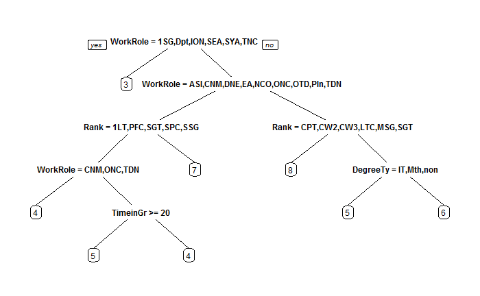

```r
set.seed(9)
split = sample.split(linearQuality$OperationalQuality, SplitRatio = 0.8)
linTrain = subset(linearQuality, split==TRUE)
linTest = subset(linearQuality, split==FALSE)
library(rpart)
library(rpart.plot)
qualityTree <- rpart(OperationalQuality ~., data =linTrain, method="class")
prp(qualityTree)
```

If we look at this model and follow the tree, rnak and work role seem to be the most important factors when looking at qulaity. The highest quality that can be see on the tree, an 8, is an officer (CPT, CW2, CW3) or NCO (MSG or SGT) that is not in certain work roles like EA, DNEA, and others. Of particular, pipeline training completion and certifications do not feature in the tree at all.

Next, lets investigate its predictive power with a confusion matrix.

```r
PredictCART = predict(qualityTree, newdata = linTest, type = "class")
table(linTest$OperationalQuality, PredictCART)
```

```
   PredictCART
    1 2 3 4 5 6 7 8 9 10
  1 0 0 0 1 0 0 0 0 0  0
  2 0 0 1 0 0 0 0 0 0  0
  3 0 0 1 0 1 0 2 0 0  0
  4 0 0 1 0 1 0 1 1 0  0
  5 0 0 0 3 0 1 0 1 0  0
  6 0 0 1 1 0 1 0 3 0  0
  7 0 0 1 0 1 0 2 1 0  0
  8 0 0 0 0 0 1 0 1 0  0
  9 0 0 0 1 0 0 0 0 0  0
```

Now, we would like to investiate a CART model using the same trick from logistic regression - lets see how well the model does with just categorizing people into ‘good’ and ‘bad’ categories for operational effectiveness.

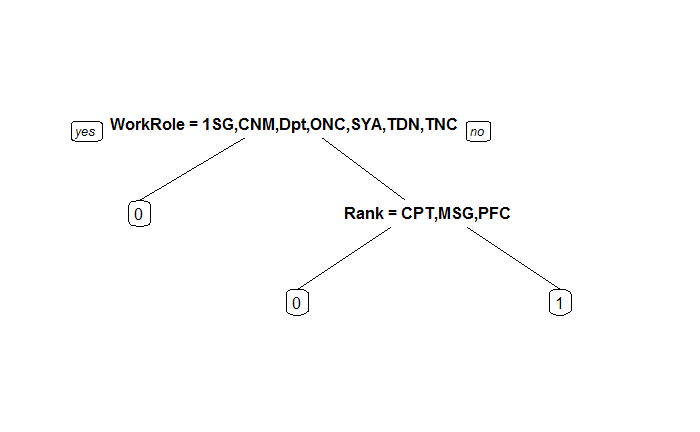

```r
qualityTreeBin <- rpart(OperationalQuality ~., data =regTrain, method="class")
prp(qualityTreeBin)
```

Once again, training metrics do not feature in the tree at all. And, once again, quality is typically a function of rank and work role alone.

Now lets look at how predictive this model is with AUC and a confusion matrix

```r
PredictCART = predict(qualityTreeBin, newdata = regTest, type = "class")
table(regTest$OperationalQuality, PredictCART)
```

```
   PredictCART
     0  1
  0  7  7
  1  7 23
```

```r
PredictROC = predict(qualityTreeBin , newdata = regTest)
PredictROC
```

```
            0         1
5   0.1304348 0.8695652
8   0.1304348 0.8695652
11  0.1304348 0.8695652
14  0.7600000 0.2400000
15  0.7600000 0.2400000
18  0.1304348 0.8695652
20  0.1304348 0.8695652
21  0.1304348 0.8695652
22  0.1304348 0.8695652
31  0.1304348 0.8695652
33  0.7600000 0.2400000
40  0.1304348 0.8695652
45  0.7600000 0.2400000
48  0.7600000 0.2400000
```

[output cut: 30 more lines]

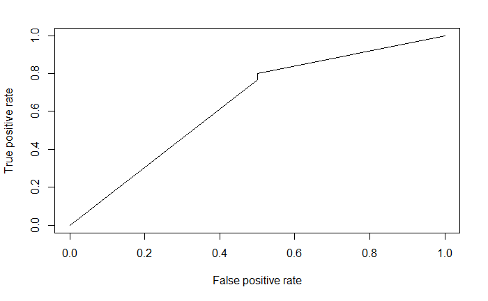

```r
pred = prediction(PredictROC[,2], regTest$OperationalQuality)
perf = performance(pred, "tpr", "fpr")
plot(perf)
```

```r
as.numeric(performance(pred, "auc")@y.values)
```

```
[1] 0.6416667
```

```r
(7+23)/nrow(regTest)
```

```
[1] 0.6818182
```

As with the logitic regression we are into the mid to high 0.6’s for accuracy ratings with the confusion matrix and the the AUC.

Lastly, we will try a random forest model, which is a more advanced implementation of CART using many trees, and look at the predictive power.

```r
library(randomForest)
qualityForest <- randomForest(OperationalQuality ~., data =linTrain)
PredictForest = predict(qualityForest, newdata = linTest, type = "class")
table(linTest$OperationalQuality, PredictForest)
```

```
   PredictForest
    3.83975476190476 4.04249761904762 4.25569523809524 4.38199696969697 4.68587222222222 4.79542912087912
  1                0                0                0                1                0                0
  2                0                0                0                0                0                0
  3                0                1                0                0                1                0
  4                1                0                0                0                0                0
  5                0                0                0                0                0                0
  6                0                0                0                0                0                1
  7                0                0                0                0                0                0
  8                0                0                1                0                0                0
  9                0                0                0                0                0                0
   PredictForest
    4.84015772560772 4.92984678654678 4.98395555555555 5.01367742257742 5.02018315018315 5.13099682539682
  1                0                0                0                0                0                0
  2                0                0                0                0                0                0
```

[output cut: 40 more lines]

Looking at the confusion matrix, it does not look like there is much gain on the CART model. This is likely becuase there is simply not enough data to run a significant amount of random trees to make a good random forest model.

All in all, the CART technique shows decent results and very good promise for a future model for discerning what factors are salient in opertionally effective Soldiers and Civilians.

This brief investigation has some key findings worth note and very much worth future investigation: 1. trained and qualified means little to nothing for an invidiuals actual operational effectiveness 2. Certs like Net+ and Sec+, and SANS courses, also mean little to nothing for an invidiuals actual operational effectiveness 3. Education matters - having a degree correlates to operational effectiveness in every case 4. Some work roles matter more than others for operational effectiveness’

Based on these findings, it is reasonable to conclude that measureing readiness for our teams based on FT & FQ numbers along with manning numbers is a mistake; these metrics matter little on the individual level and likely matter even less in the aggregate. We need a far more comprehensive study of what ‘quality’ and ‘readiness’ is actually realted to if we are to truly evaluate ourselves and make beneficial decisions for the force.